# Assignment 5 - Decision Trees

Charles Lang

November 9, 2016

For this assignment we will be using data from the Assistments Intelligent Tutoring system. This system gives students hints based on how they perform on math problems.

# Install & call libraries

```r
#install.packages("party", "rpart") this code is not working for me on either machine
library(rpart)
library(party)
```

```r
library(ggplot2)
library(knitr)
```

## Part I

```r
D1 <- read.csv("intelligent_tutor.csv", header = TRUE)
knitr::opts_chunk$set(echo = TRUE, message=FALSE, warning=FALSE)
```

## Classification Tree

First we will build a classification tree to predict which students ask a teacher for help, which start a new session, or which give up, based on whether or not the student completed a session (D1$complete) and whether or not they asked for hints (D1$hint.y).

```r
c.tree <- rpart(action ~ hint.y + complete, method="class", data=D1) #Notice the standard R notion for a formula X ~ Y

#Look at the error of this tree
printcp(c.tree)
```

```
##
## Classification tree:
## rpart(formula = action ~ hint.y + complete, data = D1, method = "class")
##
## Variables actually used in tree construction:
## [1] complete hint.y
##
## Root node error: 250/378 = 0.66138
##
## n= 378
##
##      CP nsplit rel error xerror     xstd
## 1 0.052      0     1.000  1.132 0.033734
## 2 0.012      1     0.948  1.048 0.035867
## 3 0.010      2     0.936  1.000 0.036803
```

```r
#Plot the tree
post(c.tree, file = "tree.ps", title = "Session Completion Action: 1 - Ask teacher, 2 - Start new session, 3 - Give up")
```

# Regression Tree

We want to see if we can build a decision tree to help teachers decide which students to follow up with, based on students’ performance in Assistments. We will create three groups (“teacher should intervene”, “teacher should monitor student progress” and “no action”) based on students’ previous use of the system and how many hints they use. To do this we will be building a decision tree using the “party” package. The party package builds decision trees based on a set of statistical stopping rules.

# Take a look at our outcome variable “score”

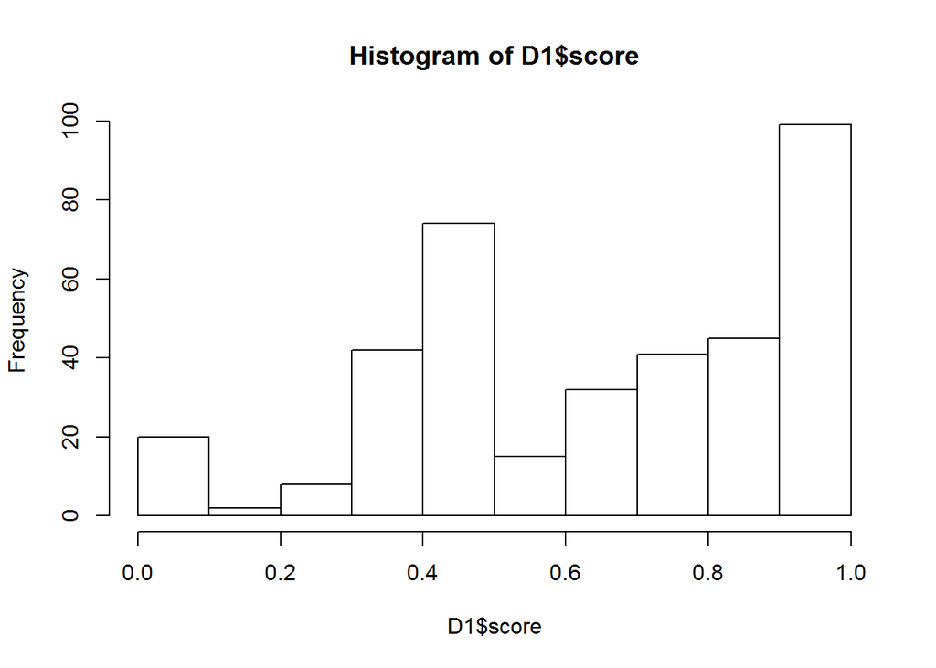

```r
hist(D1$score)
```